# problema1

Joao Paulo

15-10-2014

Q1: Assista esse vídeo com atenção. Perceba que a grande pergunta que Hans Rosling tenta responder é: temos dois mundos separados; o mundo ocidental norte rico e o resto do mundo pobre? Talvez você precise pausar o vídeo para entender, assistir mais de uma vez, etc. a)Trace um esboço do caminho que ele percorreu analisando os dados para responder essas perguntas.  
b)Anote os termos ou ideias que você não entende ainda.

Início da análise:

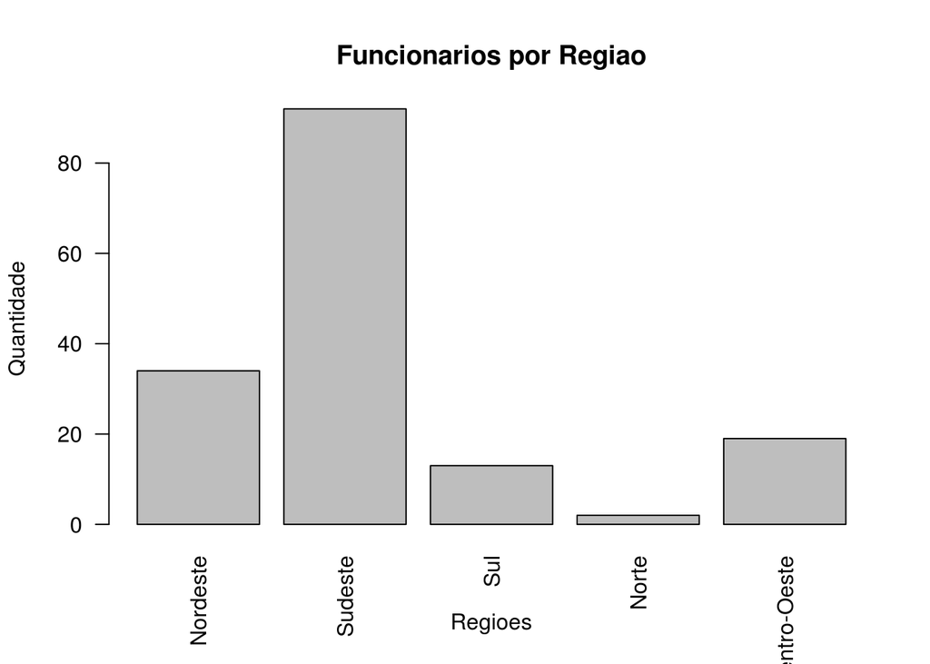

```r
library(ggplot2)
funcionario <- read.csv("./salarios-ti-regioes.csv")

funcionarioPrivada = subset(funcionario, Iniciativa.Privada.ou.Concursado =="Iniciativa Privada")
funcionarioConcursado = subset(funcionario, Iniciativa.Privada.ou.Concursado  =="Concursado")
funcionarioPosOuCertificacao = subset(funcionario, Pos.Graduacao.ou.Certificacao  =="TRUE")
#ver onde funcionarios com certificacao estao, na iniciativa privada ou concursados. e onde ganham mais

funcionarioNordeste = subset(funcionario, Regiao =="Nordeste")
funcionarioSudeste = subset(funcionario, Regiao =="Sudeste")
funcionarioSul = subset(funcionario, Regiao =="Sul")
funcionarioNorte = subset(funcionario, Regiao =="Norte")
funcionarioCentroOeste = subset(funcionario, Regiao =="Centro-oeste")

barplot(c(nrow(funcionarioNordeste), nrow(funcionarioSudeste), nrow(funcionarioSul), nrow(funcionarioNorte), nrow(funcionarioCentroOeste)), xlab = "Regioes", ylab = "Quantidade", main = "Funcionarios por Regiao", las=2, names=c("Nordeste", "Sudeste", "Sul", "Norte", "Centro-Oeste"))
```

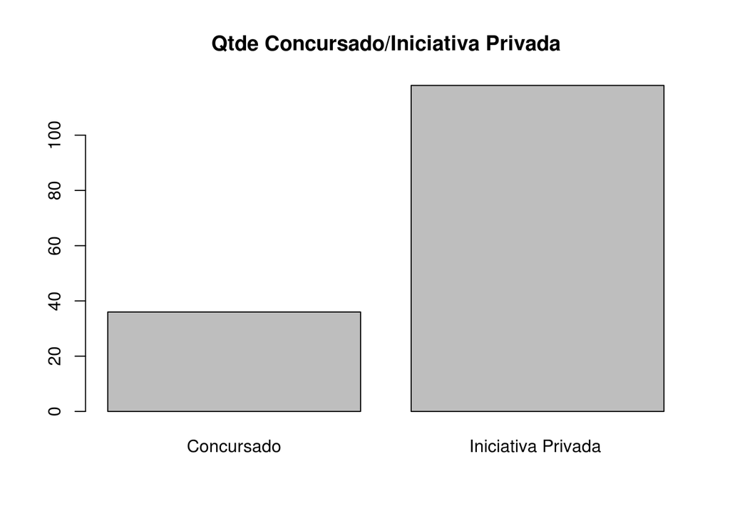

```r
barplot(c(nrow(funcionarioConcursado), nrow(funcionarioPrivada)), main = "Qtde Concursado/Iniciativa Privada", names=c("Concursado", "Iniciativa Privada "))
```

Q2: Qual o panorama geral dos profissionais de TI no Brasil sem ainda se preocupar com seus salários, apenas com sua localização, função, expertise…?

Pela análise, podemos perceber que a maioria dos funcionários se encontram na região Sudeste, sendo sua quantidade maior que a soma das outras regiões. Além disso, uma concentração bem maior na iniciativa privada, 118 contra 36. Interessante observar que na região Sudeste, os funcionários na Iniciativa Privada são 10 vezes mais presentes do que Concursados, 80 contra 8. Além disso, há uma maioria sem pós-graduação, 53 contra 39. No Centro-Oeste é onde os funcionários possuem mais tempo médio (median) de experiência profissional , 7 anos, excluindo o Norte, pois só há registro de dois funcionários dessa região nos dados.

```
##        X                     Cidade         UF     Salario.Bruto
##  Min.   :  1.00   Recife        :10   PE     :10   Min.   :  700
##  1st Qu.: 57.25   Salvador      : 8   BA     : 9   1st Qu.: 2018
##  Median :101.00   Fortaleza     : 6   CE     : 6   Median : 2900
##  Mean   : 96.12   Maceió        : 3   PB     : 5   Mean   : 4566
##  3rd Qu.:138.50   Campina Grande: 2   AL     : 3   3rd Qu.: 4600
##  Max.   :161.00   João Pessoa   : 2   SE     : 1   Max.   :42120
##                   (Other)       : 3   (Other): 0
##  Horas.Diarias   Tempo.de.Empresa Experiencia.Profissional
##  Min.   :4.000   Min.   :0.160    Min.   : 0.000
##  1st Qu.:8.000   1st Qu.:0.600    1st Qu.: 4.000
##  Median :8.000   Median :1.000    Median : 5.000
##  Mean   :7.753   Mean   :1.513    Mean   : 6.414
##  3rd Qu.:8.000   3rd Qu.:2.000    3rd Qu.: 8.000
##  Max.   :9.000   Max.   :5.000    Max.   :32.000
##
##    Iniciativa.Privada.ou.Concursado
##                    : 2
##  Concursado        : 9
##  Iniciativa Privada:23
##
##
##
##
##                                 Cargo
##  Desenvolvedor                     : 3
##  Analista de Sistemas              : 2
##  Analista de Sistemas/Desenvolvedor: 2
##  Analista de Suporte               : 2
##  Desenvolvedor Java                : 2
##                                    : 1
##  (Other)                           :22
##                               Formacao  Pos.Graduacao.ou.Certificacao
##                                   : 8   Mode :logical
##  Ciência da Computação            : 3   FALSE:17
##  Bacharel em Ciência da Computação: 2   TRUE :17
##  Ciencia da Computação            : 2   NA's :0
##  ADS                              : 1
##  Analise de Sistemas              : 1
##  (Other)                          :17
##           Regiao
##  Centro-oeste: 0
##  Nordeste    :34
##  Norte       : 0
##  Sudeste     : 0
##  Sul         : 0
##
##
```

```
##        X                     Cidade         UF     Salario.Bruto
##  Min.   :  5.00   Belo Horizonte:38   MG     :47   Min.   : 500
##  1st Qu.: 35.50   Rio de Janeiro:16   SP     :25   1st Qu.:2294
##  Median : 82.00   Campinas      :11   RJ     :17   Median :3583
##  Mean   : 80.29   São Paulo     : 9   ES     : 3   Mean   :3962
##  3rd Qu.:121.25   Viçosa        : 4          : 0   3rd Qu.:5500
##  Max.   :162.00   Vitória       : 3   AL     : 0   Max.   :9500
##                   (Other)       :11   (Other): 0
##  Horas.Diarias   Tempo.de.Empresa Experiencia.Profissional
##  Min.   :4.000   Min.   :0.0000   Min.   : 0.000
##  1st Qu.:8.000   1st Qu.:0.9375   1st Qu.: 2.000
##  Median :8.000   Median :1.9550   Median : 4.000
##  Mean   :7.928   Mean   :2.1351   Mean   : 4.659
##  3rd Qu.:8.000   3rd Qu.:3.0000   3rd Qu.: 6.000
##  Max.   :9.000   Max.   :9.0000   Max.   :20.000
##
##    Iniciativa.Privada.ou.Concursado                  Cargo
##                    : 4              Desenvolvimento Java: 6
##  Concursado        : 8              Analista de Sistemas: 4
##  Iniciativa Privada:80              Desenvolvedor Java  : 4
##                                                         : 2
##                                     Analise de Sistemas : 2
##                                     Analista de Negócios: 2
##                                     (Other)             :72
##                                 Formacao  Pos.Graduacao.ou.Certificacao
##  Ciência da Computação              :17   Mode :logical
##                                     :15   FALSE:53
##  Bacharel em Ciência da Computação  :14   TRUE :39
##  Sistemas de Informação             : 4   NA's :0
##  Bacharel em Sistemas de Informações: 3
##  Graduação em Ciência da Computação : 3
##  (Other)                            :36
##           Regiao
##  Centro-oeste: 0
##  Nordeste    : 0
##  Norte       : 0
##  Sudeste     :92
##  Sul         : 0
##
##
```

```
##        X                 Cidade        UF    Salario.Bruto  Horas.Diarias
##  Min.   : 38   Curitiba     :6   PR     :6   Min.   :1800   Min.   :7.00
##  1st Qu.: 61   Porto Alegre :4   SC     :4   1st Qu.:3100   1st Qu.:8.00
##  Median : 84   Florianópolis:2   RS     :3   Median :3500   Median :8.00
##  Mean   : 83   Joinville    :1          :0   Mean   :3658   Mean   :7.96
##  3rd Qu.: 94                :0   AL     :0   3rd Qu.:4500   3rd Qu.:8.00
##  Max.   :143   Belém        :0   BA     :0   Max.   :5495   Max.   :8.48
##                (Other)      :0   (Other):0
##  Tempo.de.Empresa Experiencia.Profissional
##  Min.   :0.160    Min.   : 2.000
##  1st Qu.:0.580    1st Qu.: 3.000
##  Median :0.750    Median : 6.000
##  Mean   :1.742    Mean   : 6.192
##  3rd Qu.:1.410    3rd Qu.: 9.000
##  Max.   :6.000    Max.   :14.000
##
##    Iniciativa.Privada.ou.Concursado
##                    :0
##  Concursado        :6
##  Iniciativa Privada:7
##
##
##
##
##                                                    Cargo
##  Análise de Sistemas, Java                            :1
##  Analista Desenvolvedor Java                          :1
##  Analista de Sistemas - JAVA                          :1
##  Analista de Sistemas - Linux, Homologação de Hardware:1
##  Análista de Sistemas/VB 5, C#, Oracle                :1
##  Analista de Testes                                   :1
##  (Other)                                              :7
##                                  Formacao Pos.Graduacao.ou.Certificacao
##  Graduação em Sistemas de Informação :3   Mode :logical
##                                      :1   FALSE:4
##  Bacharelado em Ciência da Computação:1   TRUE :9
##  Bacharel em Ciência da Computação   :1   NA's :0
##  Ciencia da Computacao               :1
##  Ciência da Computação               :1
##  (Other)                             :5
##           Regiao
##  Centro-oeste: 0
##  Nordeste    : 0
##  Norte       : 0
##  Sudeste     : 0
##  Sul         :13
##
##
```

```
##        X               Cidade         UF     Salario.Bruto
##  Min.   :  2.00   Brasília:12   DF     :16   Min.   : 1200
##  1st Qu.: 18.50   Brasilia: 4   GO     : 2   1st Qu.: 3995
##  Median : 48.00   Goiânia : 2   MT     : 1   Median : 5000
##  Mean   : 55.32   Cuiabá  : 1          : 0   Mean   : 5620
##  3rd Qu.: 73.00           : 0   AL     : 0   3rd Qu.: 6300
##  Max.   :154.00   Belém   : 0   BA     : 0   Max.   :15000
##                   (Other) : 0   (Other): 0
##  Horas.Diarias   Tempo.de.Empresa Experiencia.Profissional
##  Min.   :7.000   Min.   : 0.160   Min.   : 0.250
##  1st Qu.:8.000   1st Qu.: 0.745   1st Qu.: 4.000
##  Median :8.000   Median : 1.300   Median : 7.000
##  Mean   :7.895   Mean   : 2.624   Mean   : 7.192
##  3rd Qu.:8.000   3rd Qu.: 4.000   3rd Qu.:11.000
##  Max.   :9.000   Max.   :12.000   Max.   :15.000
##
##    Iniciativa.Privada.ou.Concursado
##                    : 2
##  Concursado        :11
##  Iniciativa Privada: 6
##
##
##
##
##                                                                                    Cargo
##  Administrador de Redes                                                               : 1
##  Análise de Requisitos (EA); Programação (Ruby + Flex)                                : 1
##  Analista de Negócio                                                                  : 1
##  Analista de negocios/Analista de Suporte/Analista de sistemas                        : 1
##  Analista de Qualidade de Software/ CMMI, MPS.BR, EPF Composer, APF, Qualidade, Testes: 1
##  Analista de Sistemas - Desenvolvimento                                               : 1
##  (Other)                                                                              :13
##                                Formacao Pos.Graduacao.ou.Certificacao
##                                    :5   Mode :logical
##  Bacharel em Ciência da Computação :2   FALSE:6
##  Bacharel em Ciencias da Computação:2   TRUE :13
##  Engenharia de Computação          :2   NA's :0
##  Analista de Sistemas              :1
##  Bacharel em Sistemas de Informação:1
##  (Other)                           :6
##           Regiao
##  Centro-oeste:19
##  Nordeste    : 0
##  Norte       : 0
##  Sudeste     : 0
##  Sul         : 0
##
##
```

```
##        X                      Cidade        UF    Salario.Bruto
##  Min.   : 70.00   Belém          :1   PA     :1   Min.   :1105
##  1st Qu.: 92.25   Ji-Paraná      :1   RO     :1   1st Qu.:1829
##  Median :114.50                  :0          :0   Median :2552
##  Mean   :114.50   Belo Horizonte :0   AL     :0   Mean   :2552
##  3rd Qu.:136.75   Belo Horizonte :0   BA     :0   3rd Qu.:3276
##  Max.   :159.00   Brasilia       :0   CE     :0   Max.   :4000
##                   (Other)        :0   (Other):0
##  Horas.Diarias  Tempo.de.Empresa Experiencia.Profissional
##  Min.   :7.00   Min.   :2.00     Min.   :10.0
##  1st Qu.:7.25   1st Qu.:2.75     1st Qu.:10.5
##  Median :7.50   Median :3.50     Median :11.0
##  Mean   :7.50   Mean   :3.50     Mean   :11.0
##  3rd Qu.:7.75   3rd Qu.:4.25     3rd Qu.:11.5
##  Max.   :8.00   Max.   :5.00     Max.   :12.0
##
##    Iniciativa.Privada.ou.Concursado
##                    :0
##  Concursado        :2
##  Iniciativa Privada:0
##
##
##
##
##                                      Cargo
##  Analista de TI e Redes                 :1
##  Técnico de Suporte (Redes e Servidores):1
##                                         :0
##  Administrador de Banco de Dados        :0
##  Administrador de Dados                 :0
##  Administrador de Redes                 :0
##  (Other)                                :0
##                           Formacao Pos.Graduacao.ou.Certificacao
##  Ciência da Computação        :1   Mode :logical
##  Licenciatura Plena Matemática:1   FALSE:1
##                               :0   TRUE :1
##  ADS                          :0   NA's :0
##  Analise de Sistemas          :0
##  Analista de Sistemas         :0
##  (Other)                      :0
##           Regiao
##  Centro-oeste:0
##  Nordeste    :0
##  Norte       :2
##  Sudeste     :0
##  Sul         :0
##
##
```

```
##        X                     Cidade         UF     Salario.Bruto
##  Min.   :  2.00   Brasília      : 6   DF     : 8   Min.   : 1105
##  1st Qu.: 37.25   Porto Alegre  : 3   PB     : 3   1st Qu.: 3298
##  Median : 66.00   Recife        : 3   PE     : 3   Median : 4250
##  Mean   : 69.89   Belo Horizonte: 2   RJ     : 3   Mean   : 4923
##  3rd Qu.: 90.25   Brasilia      : 2   SC     : 3   3rd Qu.: 5496
##  Max.   :159.00   Florianópolis : 2   CE     : 2   Max.   :15000
##                   (Other)       :18   (Other):14
##  Horas.Diarias  Tempo.de.Empresa Experiencia.Profissional
##  Min.   :6.00   Min.   : 0.080   Min.   : 0.00
##  1st Qu.:8.00   1st Qu.: 0.580   1st Qu.: 2.00
##  Median :8.00   Median : 1.000   Median : 5.00
##  Mean   :7.75   Mean   : 2.021   Mean   : 5.02
##  3rd Qu.:8.00   3rd Qu.: 3.125   3rd Qu.: 6.00
##  Max.   :8.00   Max.   :12.000   Max.   :14.00
##
##    Iniciativa.Privada.ou.Concursado
##                    : 0
##  Concursado        :36
##  Iniciativa Privada: 0
##
##
##
##
##                                                    Cargo
##  Analista de Sistemas                                 : 3
##  Analista de Negócios                                 : 2
##  Analista de TI                                       : 2
##  Desenvolvedor                                        : 2
##                                                       : 1
##  Análise de Requisitos (EA); Programação (Ruby + Flex): 1
##  (Other)                                              :25
##                                Formacao  Pos.Graduacao.ou.Certificacao
##  Ciência da Computação             : 7   Mode :logical
##                                    : 6   FALSE:16
##  Engenharia de Computação          : 3   TRUE :20
##  Analista de Sistemas              : 2   NA's :0
##  Bacharel em Ciência da Computação : 2
##  Bacharel em Ciencias da Computação: 2
##  (Other)                           :14
##           Regiao
##  Centro-oeste:11
##  Nordeste    : 9
##  Norte       : 2
##  Sudeste     : 8
##  Sul         : 6
##
##
```

```
##        X                     Cidade         UF     Salario.Bruto
##  Min.   :  1.00   Belo Horizonte:34   MG     :43   Min.   :  500
##  1st Qu.: 45.25   Rio de Janeiro:14   SP     :22   1st Qu.: 2196
##  Median : 92.50   Campinas      :11   RJ     :14   Median : 3200
##  Mean   : 85.87   Salvador      : 8   BA     : 9   Mean   : 4008
##  3rd Qu.:125.50   São Paulo     : 8   PE     : 7   3rd Qu.: 5094
##  Max.   :162.00   Recife        : 7   DF     : 6   Max.   :42120
##                   (Other)       :36   (Other):17
##  Horas.Diarias   Tempo.de.Empresa Experiencia.Profissional
##  Min.   :4.000   Min.   :0.000    Min.   : 0.000
##  1st Qu.:8.000   1st Qu.:1.000    1st Qu.: 3.000
##  Median :8.000   Median :1.620    Median : 5.000
##  Mean   :7.928   Mean   :2.136    Mean   : 5.607
##  3rd Qu.:8.000   3rd Qu.:2.958    3rd Qu.: 7.000
##  Max.   :9.000   Max.   :9.000    Max.   :32.000
##
##    Iniciativa.Privada.ou.Concursado                  Cargo
##                    :  0             Desenvolvedor Java  : 6
##  Concursado        :  0             Desenvolvimento Java: 6
##  Iniciativa Privada:118             Analista de Sistemas: 3
##                                                         : 2
##                                     Analise de Sistemas : 2
##                                     Analista de Suporte : 2
##                                     (Other)             :97
##                                 Formacao  Pos.Graduacao.ou.Certificacao
##                                     :18   Mode :logical
##  Bacharel em Ciência da Computação  :16   FALSE:63
##  Ciência da Computação              :15   TRUE :55
##  Graduação em Ciência da Computação : 4   NA's :0
##  Sistemas de Informação             : 4
##  Bacharel em Sistemas de Informações: 3
##  (Other)                            :58
##           Regiao
##  Centro-oeste: 6
##  Nordeste    :23
##  Norte       : 0
##  Sudeste     :80
##  Sul         : 7
##  NA's        : 2
##
```

Q3: Os salários estão bem distribuídos no intervalo que vai do menor salário para o maior salário? Ou será que os salários são muito concentrados em um intervalo pequeno de valores? Será que existem salários atípicos (outliers)?

Os salários dos concursados estão melhores distribuidos do que os da Iniciativa Privada e são ligeiramente melhores, a mediana do salário dos concursados é maior que da Iniciativa Privada, porém contém mais outliers, enquanto o da iniciativa privada indicam outliers mais extremos, tanto o maior salário quanto o menor diferem muito da média. Analisando as regiões dá pra perceber que no Nordeste vemos esses outliers de uma forma mais acentuada.

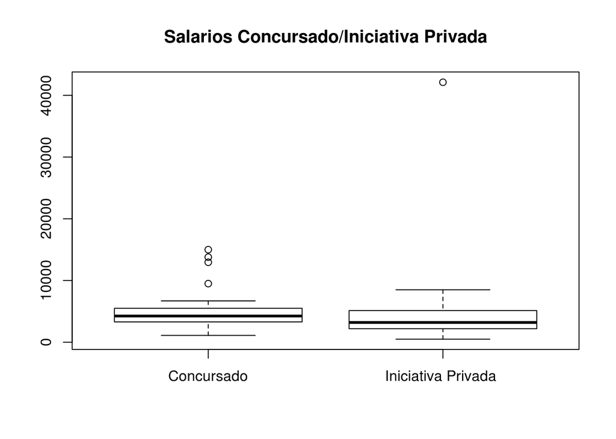

```r
boxplot(funcionarioConcursado$Salario.Bruto, funcionarioPrivada$Salario.Bruto,  main = "Salarios Concursado/Iniciativa Privada", names=c("Concursado", "Iniciativa Privada "))
```

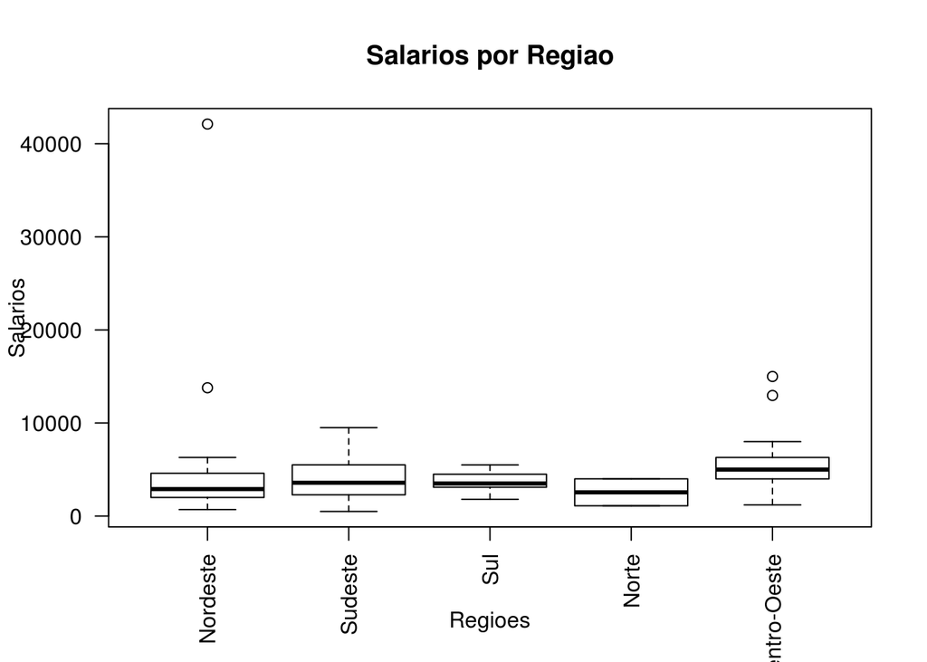

```r
boxplot(funcionarioNordeste$Salario.Bruto, funcionarioSudeste$Salario.Bruto, funcionarioSul$Salario.Bruto, funcionarioNorte$Salario.Bruto, funcionarioCentroOeste$Salario.Bruto, xlab = "Regioes", ylab = "Salarios", main = "Salarios por Regiao", las=2, names=c("Nordeste", "Sudeste", "Sul", "Norte", "Centro-Oeste"))
```

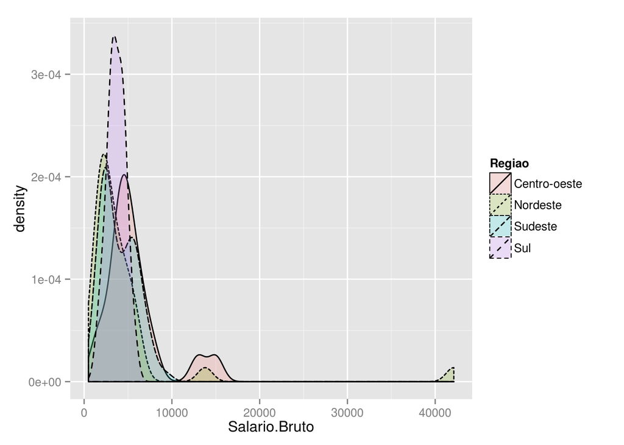

```r
ggplot(funcionario, aes(Salario.Bruto, fill=Regiao, lty=Regiao)) + geom_density(alpha=.2)
```

Q4:A distribuição que você encontrou é a que você esperava sem olhar os dados? Se não é, você tem alguma suspeita da razão para a diferença?

```
Não. Esperava que a média salarial das regiões Sul e Sudeste fossem as maiores, porém elas ficam abaixo das regiões Nordeste e Centro-Oeste. Possivelmente os casos atípicos de salários causam anomalias nos resultados, como é o caso do Nordeste, que possui um salário extraordinariamente maior que todos os outros. Uma análise possível no caso do Centro-Oeste é que, além de ter uma amostra menor nos dados, esses profissionais são bem qualificados(a maioria possui pós/certificação), sua maioria se concentra em Brasília, possuem muito tempo de experiência profissional em média e a maior parte é concursada.
```

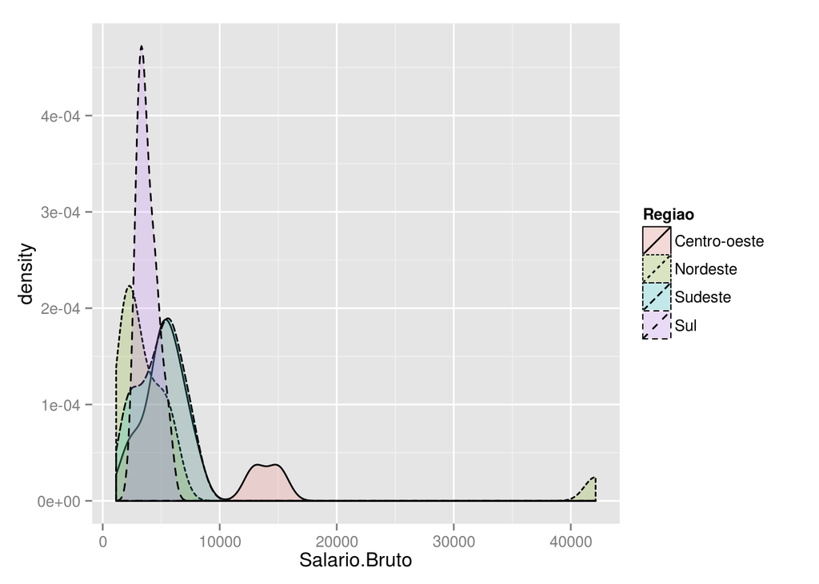

```r
#visualização da distribuição de salários de quem possui pós ou certificação
ggplot(funcionarioPosOuCertificacao, aes(Salario.Bruto, fill=Regiao, lty=Regiao)) + geom_density(alpha=.2)
```

Q6: Se um profissional de TI deseja ter um salario melhor, qual a(s) dica(s) para ele?

Seguir carreira de concursado dá uma média/mediana maior de salário, porém a Iniciativa Privada recompensa melhor casos atípicos. Já em relação a localização, a região Centro-Oeste é a mais indicada, pois paga melhor que as demais, além de procurar algum tipo de especialização ou pós graduação, uma vez que esses profissionais possuem salários maiores que os demais.